# STA 141A Fundamentals of Statistical Data Science - Homework 2

## Hints

It is helpful to think about how a human would work this out. Note that

- `rep(x, each = a)` repeats each element of x a times, producing a vector of length `m*a`.
- `rep(y, each = b)` repeats each element of y b times, producing a vector of length `n*b`.
- `c(rep(x, each = a), rep(y, each = b))` combines these two vectors, producing a vector of length `m*a + n*b`.  
  Lets call this vector “w”.
- `rep(c(rep(x, each = a), rep(y, each = b)), times = t)` repeats the whole vector w t times, producing a vector of length `t * (m*a + n*b)`.

With this knowledge, we can work backwards to the answer. Suppose for example that k = 130, m = 11, n = 8, a = 2, b = 3, and t = 4.

- The outermost call to `rep()` just makes t = 4 copies of a vector w of length `m*a + n*b =` 46.
- k = 130 divided by 46 gives 2 with a remainder of r = 38. (How would you calculate this remainder in R?)
- These calculations tell us that we’re going to skip over 2 copies of w and then look for the 38th element of w.  
  Be careful here: what element of w would you be seeking if the remainder calculated in the last step were 0?
- Next, to determine whether we’re looking for an element of the original x or y vector, we just need to know whether the remainder from the last step was less than or equal to m*a = 22 or not.  
  In the present example r = 38 is greater than 22, so we are looking for an element of y.
- If we are looking for an element of y, then we can subtract m*a from r and ignore x. Otherwise, we can ignore y.  
  In the present example, we are looking for an element of y, so r is changed to 16.
- Next, depending on whether we are looking for an element of x or y, we have to use r with either a or b to determine the original index. Let d represent the value of a or b, depending on whether we are looking for an element of x or of y. Thus, in the present example, d = 3.
- Now you just need to figure out how to do the necessary arithmetic with r and d to get the index.

In outline, the function should look something like this. (Again, be careful to do the right thing in the first step if `m*a + n*b` happens to divide evenly into k.

calculate the remainder r when k is divided by `m*a + n*b`  
**if** r is less than or equal to m*a  
set v to “x”  
set d to a  
**else**  
set v to “y”  
set r to r - m*a  
set d to b  
**endif**  
use r and d to calculate i  
**return** results

Again, you are not allowed to use the `rep()` function in your solution. Thus, a function like the following is *NOT* allowed, even though it returns the correct solution. (Of course there is nothing stopping you from using this version to check that your own solution is working correctly.)

```r
forbidden <- function(k, m, n, a, b, t) {
    if (any(k > (t * (m * a + n * b)))) warning("First argument is out of range")
    xy <- rep(c(rep("x", each = m*a), rep("y", each = n*b)),
              times = t)
    ij <- rep(c(rep(1:m, each = a), rep(1:n, each = b)),
              times = t)
    list(src_vector = xy[k], src_index = ij[k])
    }
```

One last comment: the forbidden version of the function provided above will work correctly if the argument k is an integer *vector*. It is a good exercise to try to modify your solution so that it also works with vector k.

2. Consider the report: [A PHASE 1/2/3, PLACEBO-CONTROLLED, RANDOMIZED, OBSERVER-BLIND, DOSE-FINDING STUDY TO EVALUATE THE SAFETY, TOLERABILITY, IMMUNOGENICITY, AND EFFICACY OF SARS-COV-2 RNA VACCINE CANDIDATES AGAINST COVID-19 IN HEALTHY INDIVIDUALS (pages 99-101)]. Let $\theta$ be the probability that a subject who fell ill with Covid-19 is from the treatment group and $1-\theta$ the probability that the subject is from the control group. Assuming that 94 subjects fell ill to Covid-19 (with a sample efficacy above 90%) and at most 8 of those 94 subjects were vaccinated. Write a report (Introduction, Methods, Results and Conclusions) assuming:
1. A Beta prior for $\theta$: $p(\theta)$=Beta$($a=0.5,b=0.5$)$, where $a$ and $b$ are the shape parameters of the Beta distribution. Plot the prior, likelihood and posterior as function of $\theta$.

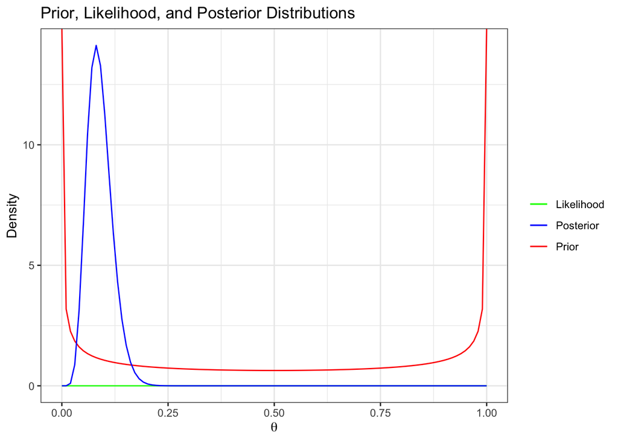

```r
library(ggplot2)
library(scales)

# Define the parameters
a <- 0.5
b <- 0.5
n <- 94
k <- 8

# Define the prior distribution
prior <- function(theta) dbeta(theta, a, b)

# Define the likelihood function
likelihood <- function(theta) theta^k * (1-theta)^(n-k)

# Define the posterior distribution
posterior <- function(theta) dbeta(theta, a+k, b+n-k)

# Plot the prior, likelihood, and posterior distributions
theta_values <- seq(0, 1, length.out = 100)
prior_values <- prior(theta_values)
likelihood_values <- likelihood(theta_values)
posterior_values <- posterior(theta_values)

df <- data.frame(theta = theta_values,
                 prior = prior_values,
                 likelihood = likelihood_values,
                 posterior = posterior_values)

ggplot(df, aes(x = theta)) +
  geom_line(aes(y = prior, color = "Prior")) +
  geom_line(aes(y = likelihood, color = "Likelihood")) +
  geom_line(aes(y = posterior, color = "Posterior")) +
  scale_color_manual("", values = c("Prior" = "red", "Likelihood" = "green", "Posterior" = "blue")) +
  labs(x = expression(theta), y = "Density", title = "Prior, Likelihood, and Posterior Distributions") +
  theme_bw()
```